# Лабораторная работа №5

Управление системными службами

Максат Хемраев

Российский университет дружбы народов, Москва, Россия

21 сентября 2025

# Цель работы

## Основная цель

Получить навыки управления системными службами операционной системы посредством **systemd**.

# Ход выполнения работы

## Проверка службы vsftpd

- Получены права администратора
- Проверен статус службы **vsftpd**
- Сервис отсутствует в системе

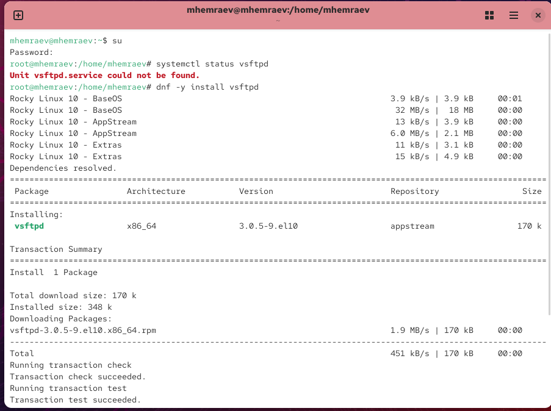

Проверка статуса службы vsftpd

## Установка vsftpd

- Установлен пакет **vsftpd** через dnf
- Установка завершена успешно

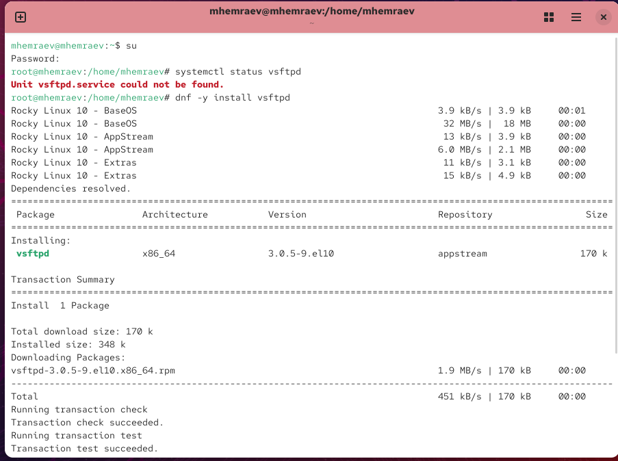

Установка пакета vsftpd

## Запуск vsftpd

- Служба **vsftpd** запущена
- Проверка статуса: сервис активен, но отключён в автозагрузке

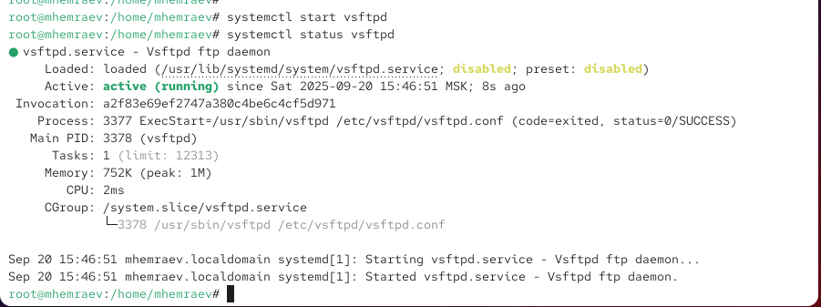

Запуск и проверка службы vsftpd

## Автозапуск vsftpd

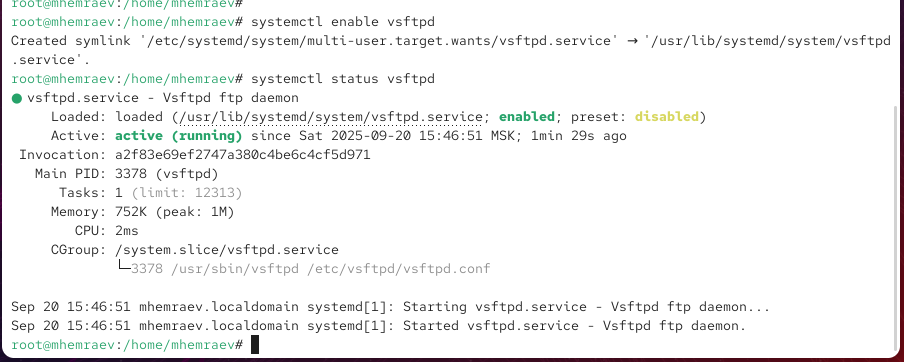

## Символические ссылки vsftpd

- Просмотрены ссылки в каталоге systemd
- При отключённом автозапуске ссылки нет
- После включения автозапуска ссылка создана

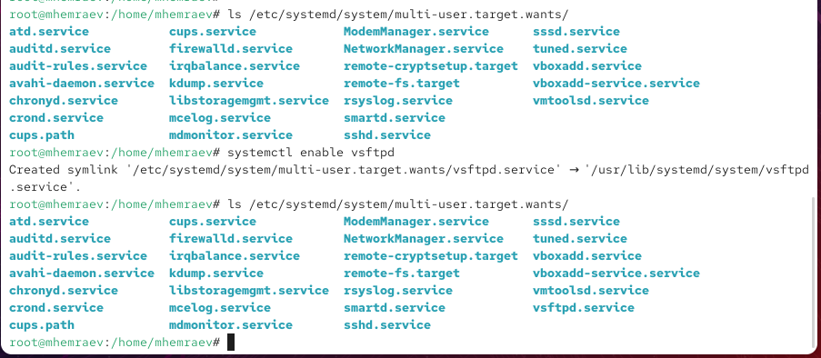

Символические ссылки vsftpd

## Зависимости vsftpd

- Проверены зависимости юнита **vsftpd**
- Сервис запускается в рамках multi-user.target
- Также просмотрены обратные зависимости

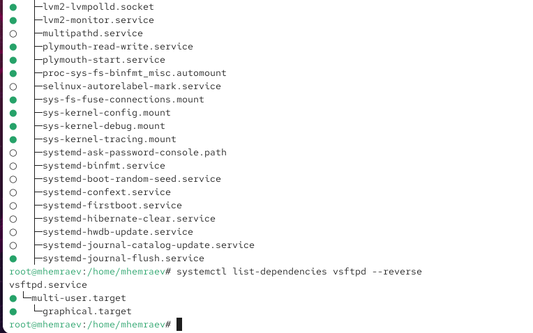

Зависимости службы vsftpd

## Установка iptables

- Установлен пакет **iptables** и модули
- Завершено успешно

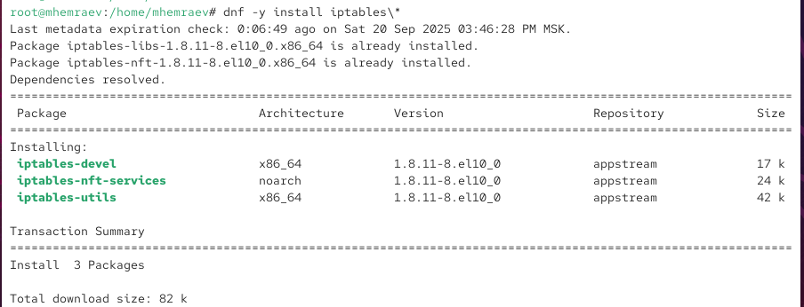

Установка iptables

## Проверка firewalld и iptables

- Статус firewalld: активен
- Статус iptables: установлен, но неактивен

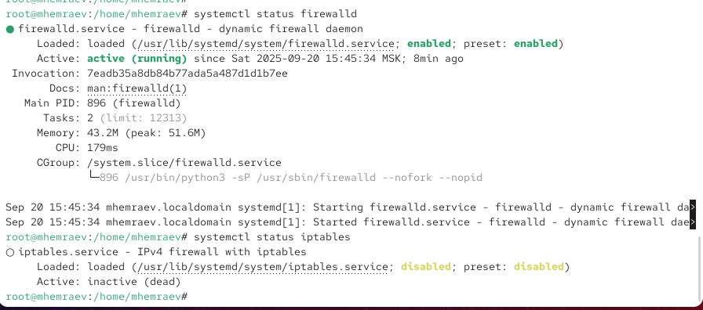

Проверка статуса firewalld и iptables

## Конфликт сервисов

- При запуске **firewalld** iptables отключается
- При запуске **iptables** firewalld останавливается

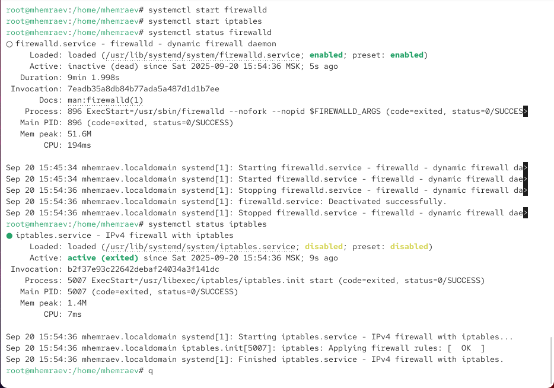

Запуск и остановка конфликтующих сервисов

## Анализ юнитов

- В файле **firewalld.service** указано: Conflicts=iptables.service

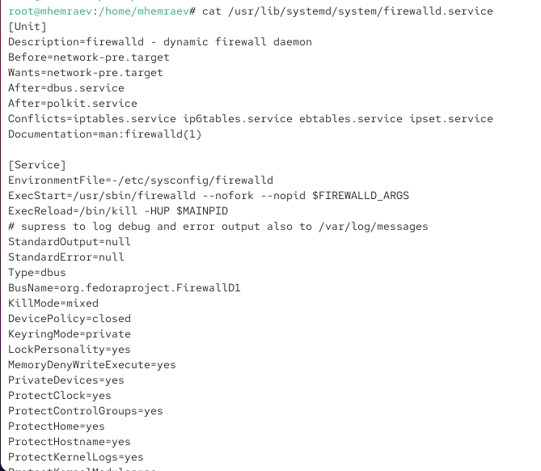

Файл firewalld.service

## Анализ юнитов

- В iptables.service нет явного конфликта

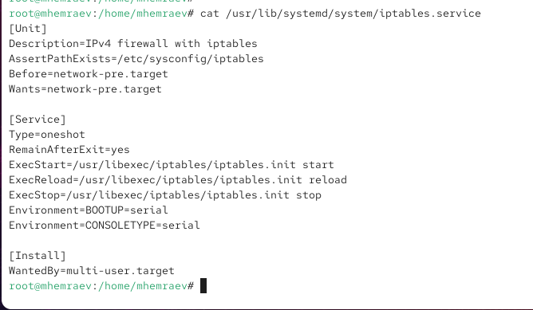

Файл iptables.service

## Маскирование iptables

- Остановлен iptables
- Замаскирован с помощью systemctl mask
- Создана ссылка на /dev/null

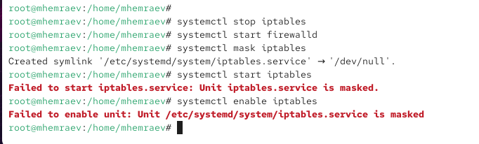

Замаскированный сервис iptables

## Изолируемые цели

- Определён список изолируемых целей через AllowIsolate=yes

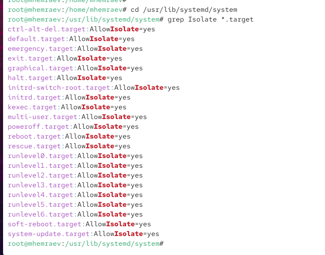

Список изолируемых целей

## Изменение цели по умолчанию

- Цель по умолчанию: graphical.target
- Изменена на multi-user.target (текстовый режим)

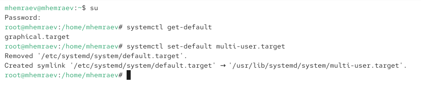

Изменение цели по умолчанию

## Возврат к графическому режиму

- После перезагрузки система запустилась в текстовом режиме
- Цель изменена обратно на graphical.target
- ОС снова загрузилась с графическим интерфейсом

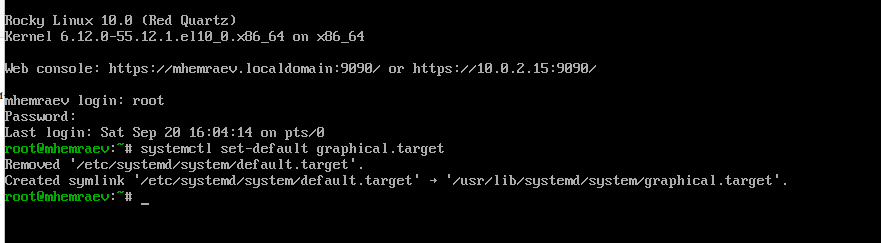

Возврат к графической цели по умолчанию

# Заключение

- Изучены механизмы управления системными службами
- Освоено добавление и удаление сервисов из автозапуска
- Рассмотрены конфликты между iptables и firewalld
- Получены навыки работы с изолируемыми целями и установкой цели по умолчанию